# Manner predicting using Machine Learning

LiuBo

6/18/2017

## Summary

This is a course project about practical machine learning, The goal of your project is to predict the manner using the dataset.

I built your model,

how you used cross validation,

what you think the expected out of sample error is, and why you made the choices you did.

### Introduction

Using devices such as Jawbone Up, Nike FuelBand, and Fitbit it is now possible to collect a large amount of data about personal activity relatively inexpensively. These type of devices are part of the quantified self movement Â– a group of enthusiasts who take measurements about themselves regularly to improve their health, to find patterns in their behavior, or because they are tech geeks.

One thing that people regularly do is quantify how much of a particular activity they do, but they rarely quantify how well they do it. In this data set, the participants were asked to perform barbell lifts correctly and incorrectly in 5 different ways. More information is available from the website here: http://groupware.les.inf.puc-rio.br/har (see the section on the Weight Lifting Exercise Dataset).

In this project, the goal will be to use data from accelerometers on the belt, forearm, arm, and dumbell of 6 participants toto predict the manner in which praticipants did the exercise.

The dependent variable or response is the “classe” variable in the training set.

### Loading Data

The data for this project come from this source: http://groupware.les.inf.puc-rio.br/har  
Load the train data and test data.

```r
setwd('/Users/freefrog/Studing/DataScience/Practical_ML')

Train_Data <- read.csv('pml-training.csv',na.strings=c("", "NA", "NULL"))
Test_Data <- read.csv('pml-testing.csv', na.strings=c("", "NA", "NULL"))

dim(Train_Data);dim(Test_Data)
```

```
## [1] 19622   160
```

```
## [1]  20 160
```

There are 160 variables, and we will predict the “classe” variable which represent the Participants’ manner.

### Cleaning the Data

In this section, we will remove variables that  
- Have too many NA values.  
- Unrelated variables. (Since the testing dataset has no time-dependence, these values are useless).  
- Low variance variables. - Highly correlated variables.

```r
# Remove variables that contain NA values
Training <- Train_Data[,colSums(is.na(Train_Data))==0]
dim(Training)
```

```
## [1] 19622    60
```

```r
# Remove unrelated variables
remove = c('X', 'user_name', 'raw_timestamp_part_1', 'raw_timestamp_part_2', 'cvtd_timestamp', 'new_window', 'num_window')
Training <- Training[,-which(names(Training) %in% remove)]
dim(Training)
```

```
## [1] 19622    53
```

```r
# Remove low variance variables
library(caret)
zeroVar= nearZeroVar(Training[,sapply(Training, is.numeric)],
                     saveMetrics = TRUE)
Training = Training[,zeroVar[, 'nzv']==0]
dim(Training)
```

```
## [1] 19622    53
```

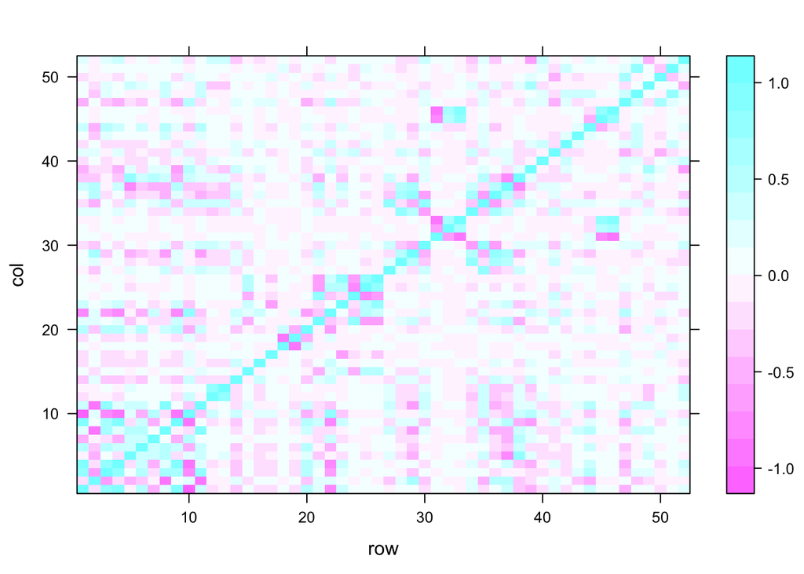

```r
# Remove highly correlated variables (90%)
corrMatrix <- cor(Training[sapply(Training, is.numeric)])

corrDF <- expand.grid(row = 1:dim(corrMatrix)[1],
                      col = 1:dim(corrMatrix)[2])
corrDF$correlation <- as.vector(corrMatrix)
levelplot(correlation ~ row+ col, corrDF)
```

```r
High_cor_var = findCorrelation(corrMatrix,
                   cutoff = .90,
                   verbose = TRUE)
```

```
## Compare row 10  and column  1 with corr  0.992
##   Means:  0.27 vs 0.168 so flagging column 10
## Compare row 1  and column  9 with corr  0.925
##   Means:  0.25 vs 0.164 so flagging column 1
## Compare row 9  and column  4 with corr  0.928
##   Means:  0.233 vs 0.161 so flagging column 9
## Compare row 8  and column  2 with corr  0.966
##   Means:  0.245 vs 0.157 so flagging column 8
## Compare row 19  and column  18 with corr  0.918
##   Means:  0.091 vs 0.158 so flagging column 18
## Compare row 46  and column  31 with corr  0.914
##   Means:  0.101 vs 0.161 so flagging column 31
## Compare row 46  and column  33 with corr  0.933
##   Means:  0.083 vs 0.164 so flagging column 33
## All correlations <= 0.9
```

```r
Training = Training[, -High_cor_var]
dim(Training)
```

```
## [1] 19622    46
```

### Split data

Then split the training data into Training and Testing data for cross validation..

```r
inTrain <- createDataPartition(y=Training$classe, p=.7, list=FALSE)

Training_Data <- Training[inTrain,]
Testing_Data <- Training[-inTrain,]

dim(Training_Data);dim(Testing_Data)
```

```
## [1] 13737    46
```

```
## [1] 5885   46
```

## Fitting the Model

### Decision Tree Model

Now we fit a Decision tree Modele to these data, and plot it.

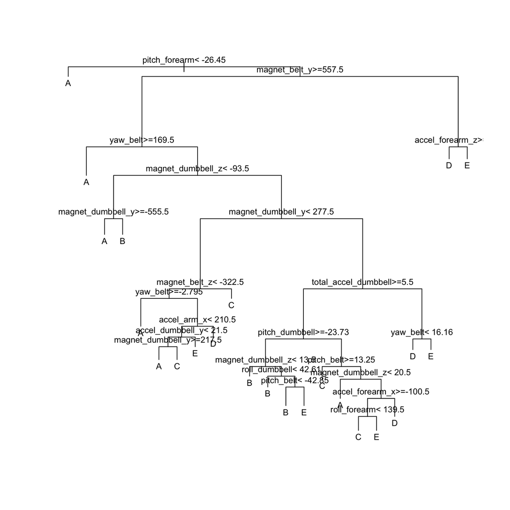

```r
library(rpart)
set.seed(12345)
modFitDT <- rpart(classe ~ ., data = Training_Data,
                  method="class",
                  control = rpart.control(method = "cv",
                                          number = 10))
plot(modFitDT)
text(modFitDT,cex=.8)
```

Predicting with decision tree model to check the performance on the testing data for cross validation.

```r
library('e1071')
Pre_Tree <- predict(modFitDT, Testing_Data, type = "class")
confusionMatrix(Pre_Tree, Testing_Data$classe)
```

```
## Confusion Matrix and Statistics
##
##           Reference
## Prediction    A    B    C    D    E
##          A 1381  146   15   10  128
##          B   13  521   29   44   33
##          C   88  235  852  138   91
##          D  174  134   75  684  108
##          E   18  103   55   88  722
##
## Overall Statistics
##
##                Accuracy : 0.7069
##                  95% CI : (0.6951, 0.7185)
##     No Information Rate : 0.2845
##     P-Value [Acc > NIR] : < 2.2e-16
##
##                   Kappa : 0.6302
##  Mcnemar's Test P-Value : < 2.2e-16
##
## Statistics by Class:
##
##                      Class: A Class: B Class: C Class: D Class: E
## Sensitivity            0.8250  0.45742   0.8304   0.7095   0.6673
## Specificity            0.9290  0.97493   0.8864   0.9002   0.9450
## Pos Pred Value         0.8220  0.81406   0.6068   0.5821   0.7323
## Neg Pred Value         0.9303  0.88217   0.9612   0.9406   0.9265
## Prevalence             0.2845  0.19354   0.1743   0.1638   0.1839
## Detection Rate         0.2347  0.08853   0.1448   0.1162   0.1227
## Detection Prevalence   0.2855  0.10875   0.2386   0.1997   0.1675
## Balanced Accuracy      0.8770  0.71617   0.8584   0.8049   0.8062
```

### Random Forests

These methods use trees as building blocks to build more complex models.

```r
require(randomForest)
set.seed(12345)
Model_RF=randomForest(classe~.,
                      data=Training_Data,
                      ntree=100,
                      importance=TRUE)
```

we can see which variables have higher impact on the prediction using varImpPlot function.

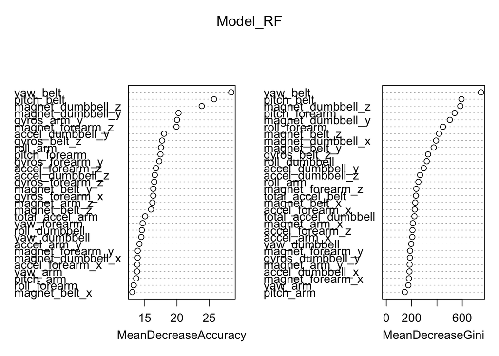

```r
varImpPlot(Model_RF,)
```

Let’s predict and get the accurancy

```r
Pre_RF <- predict(Model_RF, newdata = Testing_Data,type = "class")
accurancy <- confusionMatrix(Pre_RF, Testing_Data$classe)
accurancy$overall
```

```
##       Accuracy          Kappa  AccuracyLower  AccuracyUpper   AccuracyNull
##      0.9928632      0.9909701      0.9903653      0.9948517      0.2844520
## AccuracyPValue  McnemarPValue
##      0.0000000            NaN
```